# Tay’s top 50 songs of 2021

Song Title

Artist

**50**

Can I Get It

Adele

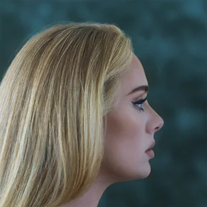

**49**

One + One

Death From Above 1979

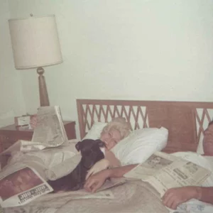

**48**

Back To Oz

Sufjan Stevens, Angelo De Augustine

[figure not shown]

**47**

Amoeba

Clairo

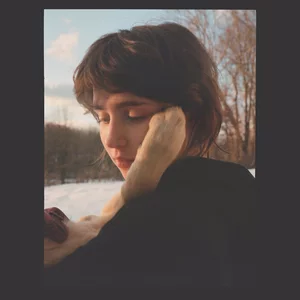

**46**

Shut Your Mouth

Terror Jr

[figure not shown]

**45**

Partner in Crime

Lucy Dacus

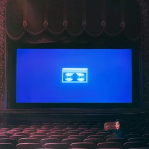

**44**

Land of Steve-O

Ovlov

[figure not shown]

**43**

MTT 420 RR

IDLES

[figure not shown]

**42**

Paddling

Squid

[figure not shown]

**41**

Black Magic

Backxwash

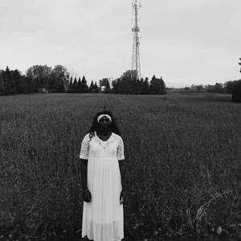

**40**

Sweat Forever

Lily Konigsberg

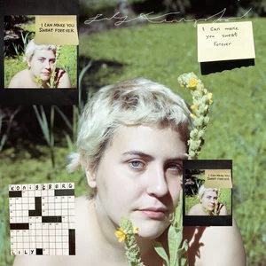

**39**

Your favorite sidekick

Underscores

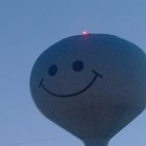

**38**

All Futures

The Armed

[figure not shown]

**37**

Expressions

Mr Twin Sister

[figure not shown]

**36**

Ben Franklin

Snail Mail

[figure not shown]

**35**

Million Times

Fiddlehead

[figure not shown]

**34**

Abscess Makes the Heart Grow

for your health

[figure not shown]

**33**

Horn Line

Jeff Rosenstock

[figure not shown]

**32**

Hardline

Julien Baker

[figure not shown]

**31**

LUMBERJACK

Tyler, The Creator

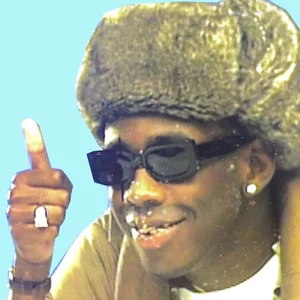

**30**

This Time

Makthaverskan

[figure not shown]

**29**

Track X

Black Country, New Road

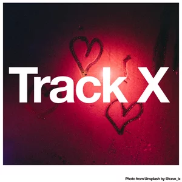

**28**

Locust Laced

Sleigh Bells

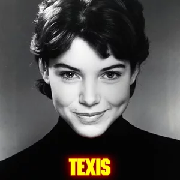

**27**

City of Glass

Raccoon City

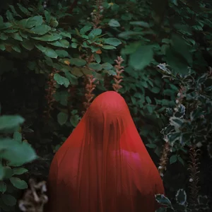

**26**

On A Mountain

Danny L Harle

[figure not shown]

**25**

The Sad Acoustic Song

Hey, Ily

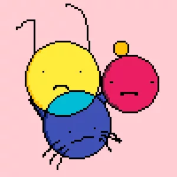

**24**

He Said She Said

Chvrches

[figure not shown]

**23**

mememe

100 gecs

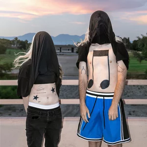

**22**

Paprika

Japanese Breakfast

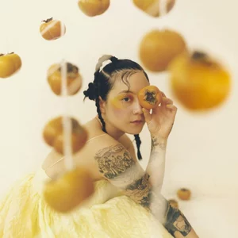

**21**

Self-Destruct

Origami Angel

[figure not shown]

**20**

Dummo Loop

Wavedash

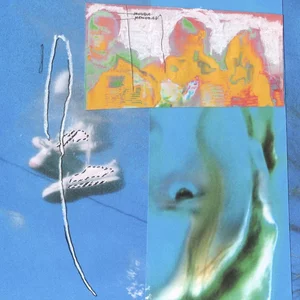

**19**

Long Distance Conjoined Twins

home is where

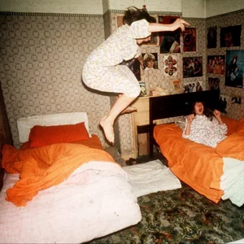

**18**

Cliffs Gaze / cliffs’ gaze at empty waters’ rise / ASHES TO SEA or NEARER TO THEE

Godspeed You! BlacK Emperor

[figure not shown]

**17**

Was

Infinity Shred

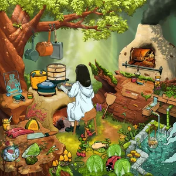

**16**

Shelter Song

Iceage

[figure not shown]

**15**

True Love

Hovvdy

[figure not shown]

**14**

Amir

serpentwithfeet

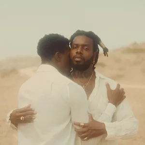

**13**

Red with Love

Pom Pom Squad

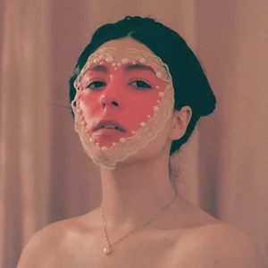

**12**

ALIEN LOVE CALL

Turnstile

[figure not shown]

**11**

Musician

Porter Robinson

[figure not shown]